# Guyang Zhang BISI CST2101 Project - Diabetes Analysis

## Context

Acoording to Swapnil Marutirao Kangralkar, diabetes is one of the most frequent diseases worldwide and the number of diabetic patients are growing over the years. The main cause of diabetes remains unknown, yet scientists believe that both genetic factors and environmental lifestyle play a major role in diabetes.

A few years ago research was done on a tribe in America which is called the Pima tribe (also known as the Pima Indians). In this tribe, it was found that the ladies are prone to diabetes very early. Several constraints were placed on the selection of these instances from a larger database. In particular, all patients were females at least 21 years old of Pima Indian heritage.

## Objective

Analyzing different aspects of Diabetes in the Pima tribe by doing Exploratory Data Analysis.

### Import the necessary libraries and Read the given dataset

```python
import numpy as np
import pandas as pd

import seaborn as sns
import matplotlib.pyplot as plt
%matplotlib inline

# You don't have to explain about these libraries below
from sklearn.preprocessing import StandardScaler
from sklearn.linear_model import LogisticRegression
from sklearn.ensemble import RandomForestClassifier
```

```python
pima = pd.read_csv("diabetes.csv")
```

```python
pima.head()
```

|  | Pregnancies | Glucose | BloodPressure | SkinThickness | Insulin | BMI | DiabetesPedigreeFunction | Age | Outcome |
| --- | --- | --- | --- | --- | --- | --- | --- | --- | --- |
| 0 | 6 | 148 | 72 | 35 | 0 | 33.6 | 0.627 | 50 | 1 |
| 1 | 1 | 85 | 66 | 29 | 0 | 26.6 | 0.351 | 31 | 0 |
| 2 | 8 | 183 | 64 | 0 | 0 | 23.3 | 0.672 | 32 | 1 |
| 3 | 1 | 89 | 66 | 23 | 94 | 28.1 | 0.167 | 21 | 0 |
| 4 | 0 | 137 | 40 | 35 | 168 | 43.1 | 2.288 | 33 | 1 |

### Are there any missing values in the `pima` dataframe?

```python
pima.isnull().values.any()
```

```
False
```

### Find the summary statistics for all variables and explain all the statistical measures for Pregnancies.

```python
pima.iloc[:,:8].describe()
```

|  | Pregnancies | Glucose | BloodPressure | SkinThickness | Insulin | BMI | DiabetesPedigreeFunction | Age |
| --- | --- | --- | --- | --- | --- | --- | --- | --- |
| count | 1000.000000 | 1000.00000 | 1000.000000 | 1000.000000 | 1000.000000 | 1000.000000 | 1000.000000 | 1000.000000 |
| mean | 4.051000 | 125.21600 | 69.072000 | 20.755000 | 83.086000 | 32.664772 | 0.494090 | 33.830000 |
| std | 3.325576 | 32.27772 | 20.465328 | 16.008599 | 117.255326 | 7.563614 | 0.322158 | 11.268189 |
| min | 0.000000 | 0.00000 | 0.000000 | 0.000000 | 0.000000 | 0.000000 | 0.078000 | 21.000000 |
| 25% | 1.000000 | 102.00000 | 64.000000 | 0.000000 | 0.000000 | 28.275000 | 0.258750 | 25.000000 |
| 50% | 3.000000 | 122.00000 | 72.000000 | 24.000000 | 23.000000 | 32.800000 | 0.408500 | 30.000000 |
| 75% | 6.000000 | 146.00000 | 80.000000 | 33.000000 | 133.500000 | 36.900000 | 0.658500 | 41.000000 |
| max | 17.000000 | 199.00000 | 122.000000 | 99.000000 | 846.000000 | 67.100000 | 2.420000 | 81.000000 |

In the Pregnancies column, there are 1000 observations with mean value of 4.05, standard deviation of 3.33, minimum value is 0. The 25% first quartile is between 0 and 1. the 50% second quartile is between 1 and 3. the 75% quartile is between 3 and 6. the max value is 17

### Plot the distribution plot for the variable `'BloodPressure'`.

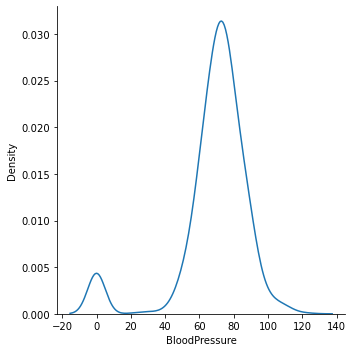

```python
sns.displot(pima['BloodPressure'],kind='kde')
plt.show()
```

```python
import statistics
statistics.mean(pima['BloodPressure'])
```

```
69.072
```

The distribution of BloodPressure values above zero have a mean value at around 70. However, many values are recorded as 0 may be incorrect. I used the new distplot function to avoid warnings. 0s are anomalies

### What is the `'BMI'` for the person having the highest `'Glucose'`?

```python
pima[pima['Glucose']==pima['Glucose'].max()]['BMI']
```

```
661    42.9
Name: BMI, dtype: float64
```

### What is the mean, median and mode of the variable `'BMI'`?

```python
m1 = pima['BMI'].mean()  #Mean
print(m1)
m2 = pima['BMI'].median()  #Median
print(m2)
m3 = pima['BMI'].mode()[0]  #Mode
print(m3)
```

```
32.664772391408796
32.8
32.0
```

Mean is 32.664772391408796 Median is 32.8 Mode is 32.0 No they are not equal.

### How many women's `'Glucose'` level is above the mean level of `'Glucose'`?

```python
pima[pima['Glucose']>pima['Glucose'].mean()].shape[0]
```

```
449
```

### Create the pairplot for variables `'Glucose'`, `'SkinThickness'` and `'DiabetesPedigreeFunction'`.

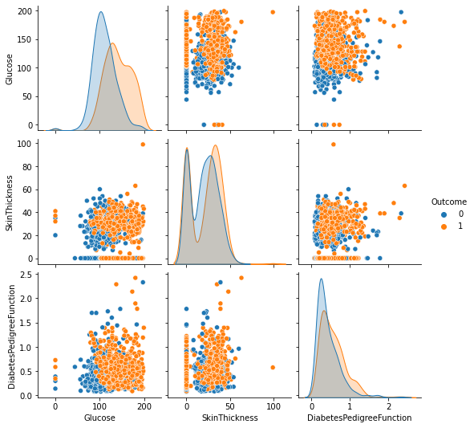

```python
sns.pairplot(data=pima, vars=['Glucose', 'SkinThickness', 'DiabetesPedigreeFunction'], hue='Outcome')
plt.show()
```

Datapoints partially overlapped in the graphs. However, high glucose may lead to a higher likelihood of diabity.

### Plot the scatterplot between `'Glucose'` and `'Insulin'`, and derive observations from the plot.

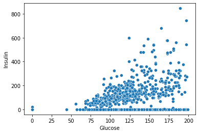

```python
sns.scatterplot(x='Glucose',y='Insulin',data=pima)
plt.show()
```

Insulin and Glucose are partially proportional.It shows positive correlation but insulin at 0 may not affect clucose level in many cases.

### Plot the boxplot for the 'Age' variable. Are there outliers?

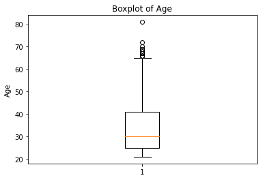

```python
plt.boxplot(pima['Age'])

plt.title('Boxplot of Age')
plt.ylabel('Age')
plt.show()
```

### Find and visualize the the correlation matrix.

```python
corr_matrix = pima.iloc[:,0:8].corr()

corr_matrix
```

|  | Pregnancies | Glucose | BloodPressure | SkinThickness | Insulin | BMI | DiabetesPedigreeFunction | Age |
| --- | --- | --- | --- | --- | --- | --- | --- | --- |
| Pregnancies | 1.000000 | 0.112930 | 0.127463 | -0.080033 | -0.064909 | 0.012920 | -0.025452 | 0.548665 |
| Glucose | 0.112930 | 1.000000 | 0.134993 | 0.050656 | 0.334175 | 0.222138 | 0.127004 | 0.255567 |
| BloodPressure | 0.127463 | 0.134993 | 1.000000 | 0.249063 | 0.117369 | 0.247275 | 0.059303 | 0.240416 |
| SkinThickness | -0.080033 | 0.050656 | 0.249063 | 1.000000 | 0.472663 | 0.387055 | 0.214026 | -0.121236 |
| Insulin | -0.064909 | 0.334175 | 0.117369 | 0.472663 | 1.000000 | 0.198281 | 0.180284 | -0.039887 |
| BMI | 0.012920 | 0.222138 | 0.247275 | 0.387055 | 0.198281 | 1.000000 | 0.163270 | 0.023921 |
| DiabetesPedigreeFunction | -0.025452 | 0.127004 | 0.059303 | 0.214026 | 0.180284 | 0.163270 | 1.000000 | 0.006809 |
| Age | 0.548665 | 0.255567 | 0.240416 | -0.121236 | -0.039887 | 0.023921 | 0.006809 | 1.000000 |

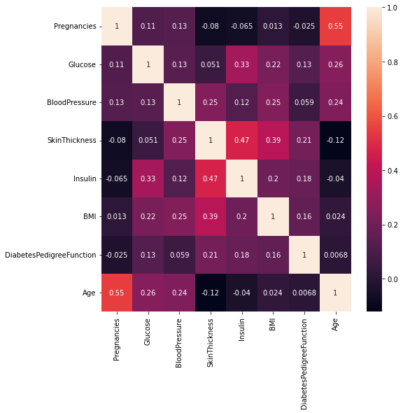

```python
plt.figure(figsize=(8,8))
sns.heatmap(corr_matrix, annot = True)

# display the plot
plt.show()
```

Age and Pregnancies have the strongest positive correlation at 0.55 which is higher than 0.4

## Model Training

### Split and scale the data

```python
# Split the data into dependent and independent variables
y = pima['Outcome']
x = pima.drop(['Outcome'], axis = 1)
```

```python
# Using StandarScaler scale the data
from sklearn.preprocessing import StandardScaler
scaler = StandardScaler()
X = scaler.fit_transform(x)
```

```python
# Splitting the data into train and test. Use test size as 15%
from sklearn.model_selection import train_test_split
x_train, x_test, y_train, y_test = train_test_split(X, y, test_size=0.15, random_state=45)
```

### Train a Logistic Regression Model. What is the Accuracy and the counts of True Positives and True Negatives did you get?

```python
# import the model
from sklearn.linear_model import LogisticRegression

# Instantiate the model
lr = LogisticRegression()

# fit the model on the train set
m = lr.fit(x_train, y_train)


# Predict on x_test
y_pred = m.predict(x_test)

# Evaluate the model
print('Accuracy of Logistic Regression model on the train set: {:.2f}'.format(m.score(x_train, y_train)))
print('Accuracy of the Logictic Regression model on the test set: {:.2f}'.format(m.score(x_test, y_test)))

from sklearn.metrics import confusion_matrix
confusion_matrix(y_test, y_pred)

#import warnings
#warnings.filterwarnings("ignore")
```

```
Accuracy of Logistic Regression model on the train set: 0.75
Accuracy of the Logictic Regression model on the test set: 0.79
```

```
array([[65, 12],
       [19, 54]], dtype=int64)
```

### Train a Random Forest Model. What is the Accuracy and the counts of True Positives and True Negatives

```python
# Import the Model
from sklearn.ensemble import RandomForestClassifier

# Instantiate the model.
rf = RandomForestClassifier(n_estimators=301, max_depth=3)

# fit the model on the train set
m2 = rf.fit(x_train, y_train)

# Predict on x_test
y_pred2 = m2.predict(x_test)

# Evaluate the Model
print('Accuracy of Random Forest model on the train set: {:.2f}'.format(m2.score(x_train, y_train)))
print('Accuracy of Random Forest model on the test set: {:.2f}'.format(m2.score(x_test, y_test)))
confusion_matrix(y_test, y_pred2)
```

```
Accuracy of Random Forest model on the train set: 0.81
Accuracy of Random Forest model on the test set: 0.84
```

```
array([[64, 13],
       [11, 62]], dtype=int64)
```

### Which model performed better?

The random forest performed better because it has a higher accuracy for both the training and test set.

## Data Dictionary

The dataset has the following information:

- Pregnancies: Number of times pregnant
- Glucose: Plasma glucose concentration over 2 hours in an oral glucose tolerance test
- BloodPressure: Diastolic blood pressure (mm Hg)
- SkinThickness: Triceps skin fold thickness (mm)
- Insulin: 2-Hour serum insulin (mu U/ml)
- BMI: Body mass index (weight in kg/(height in m)^2)
- DiabetesPedigreeFunction: A function which scores likelihood of diabetes based on family history.
- Age: Age in years
- Outcome : Class variable (0: person is not diabetic or 1: person is diabetic)